# Exercises For Plant Systems

This laboratory is the last one for the DGS and will be a collection of a few things covered in lecture in an attempt to cover some area that has been overlooked to date. As stated in the lecture, it is kind of a grab bag of techniques and will focus on parent/offspring kinds of data and network analyses.

For this lab, you will use the *gstudio* library as in the past and a few other libraries. The data for this lab is contained in the library so there is no other data to download. To start, load in the packages we will be using as:

```r
require(vegan)
```

```r
install.packages("devtools")
require(devtools)
install_github("dyerlab/popgraph")
install_github("dyerlab/gstudio")
require(gstudio)
require(popgraph)
```

If you need to update the packages for R, type `update.packages(ask=FALSE)` and they will be updated for you (the ask part is so you do not have to respond to every package that needs updating). This is a good thing to do every so often. If you do not have any of these packages, please use `install.packages()` to install them locally.

## Parent/Offspring Data

There are several kinds of biological hypotheses that can be addressed with the use of both adult and offspring data. The functionality that *gstudio* provides focuses on translations of offspring data into common formats that can be analyzed using regular routines. A underlying theme here is the use of offspring data as populations, stratified across clutches (or mom trees if you study plants), in place of populations of adults.

For this lab, we will use some example data that comes with the library from *Cornus florida* (Cornaceae), the flowering dogwood. This is an understory tree found throughout the eastern US. Load the data into memory as shown below

```r
data(cornus_florida)
cornus <- cornus_florida
summary(cornus)
```

```
##        ID            OffID              X              Y
##  Min.   :226.0   Min.   : 0.000   Min.   :1174   Min.   :1040
##  1st Qu.:468.0   1st Qu.: 0.000   1st Qu.:1533   1st Qu.:2233
##  Median :474.0   Median : 5.000   Median :1545   Median :2234
##  Mean   :462.7   Mean   : 6.774   Mean   :1543   Mean   :2326
##  3rd Qu.:474.0   3rd Qu.:12.750   3rd Qu.:1588   3rd Qu.:2234
##  Max.   :607.0   Max.   :20.000   Max.   :2286   Max.   :3534
##
##         G8           H18            N5           N10            O5
##  164:180 : 8   110:112 : 9   124:124 : 4   198:202 :10   185:193 :10
##  164:164 : 7   112:112 : 9   124:126 :23   192:198 : 9   193:193 : 9
##  156:180 : 5   104:112 : 6   124:128 : 2   190:198 : 6   181:193 : 7
##  164:168 : 5   114:116 : 5   126:126 :28   198:200 : 6   181:185 : 6
##  164:182 : 5   104:110 : 4   126:128 : 2   192:202 : 5   179:181 : 5
##  156:164 : 4   112:114 : 4   128:128 : 3   188:198 : 4   193:195 : 3
##  (Other) :28   (Other) :25                 (Other) :22   (Other) :22
```

The structure of adult/offspring data is just like any other kind of data and can consist of covariates such as physical location, size, etc. along with strata and loci. The distinction is that there must be *at least* two strata columns:

- **Individual ID** There should a column in the dataset that has identification number or names that are unique to adults. Every adult *must* have a unique identification numver. By default, functions in `gstudio` assume this column to be labeled `ID’ but you can specify it as an alternative value as an optional argument as necessary.
- **Offspring ID** To differentiate offspring from adults, the Offspring ID column should have the maternal individual (or paternal if you like) equal to 0. Offspring from this individual have non-zero values for the Offspring ID column. Offspring do not need to all have unique Offspring ID designations, just unique ones within the set of offspring with the same Individual ID. By default, functions assume this column to be labeled as `OffID’ though you are free to specify alternative labels as necessary.

Here is an example to show the distinctions using one mother/offspring family array.

```r
family <- cornus[ cornus$ID=="474",]
family
```

```
##     ID OffID    X    Y      G8     H18      N5     N10      O5
## 29 474     0 1545 2234 156:164 104:112 126:126 198:200 185:193
## 30 474     1 1545 2234 164:168 104:112 126:126 198:202 185:195
## 31 474     2 1545 2234 156:156 102:112 126:126 198:198 179:185
## 32 474     3 1545 2234 162:164 112:114 124:126 192:198 185:193
## 33 474     4 1545 2234 164:188 110:112 126:126 194:198 185:193
## 34 474     5 1545 2234 156:158 112:112 126:128 192:198 185:193
## 35 474     6 1545 2234 164:180 108:112 126:126 188:198 177:193
## 36 474     7 1545 2234 164:188 110:112 126:126 190:198 177:185
## 37 474     8 1545 2234 164:168 104:112 126:126 200:202 193:193
## 38 474     9 1545 2234 156:164 112:112 126:126 190:198 185:193
## 39 474    10 1545 2234 164:188 110:112 126:126 190:198 177:185
## 40 474    11 1545 2234 164:168 110:112 126:126 188:200 181:185
## 41 474    12 1545 2234 164:180 112:112 126:126 190:198 179:193
## 42 474    13 1545 2234 164:164 112:114 126:126 188:198 181:185
## 43 474    14 1545 2234 156:180 112:118 126:126 188:200 185:193
## 44 474    15 1545 2234 156:180 112:114 126:126 190:200 179:185
## 45 474    16 1545 2234 156:168 104:112 126:126 192:198 193:193
## 46 474    17 1545 2234 164:164 112:112 126:126 198:200 193:193
## 47 474    18 1545 2234 156:164 104:114 126:126 198:202 181:193
## 48 474    19 1545 2234 164:164 112:112 126:128 198:200 185:193
## 49 474    20 1545 2234 164:168 112:112 126:126 192:198 193:193
```

Notice that all the offspring from mom ‘474’ have the same ID and she is differentiated from the offspring by having ‘OffID=0’. In fact, all the adults in the dataset can be found as:

```r
adults <- cornus[cornus$OffID==0,]
adults
```

```
##     ID OffID    X    Y      G8     H18      N5     N10      O5
## 1  226     0 1392 3534 162:180 114:114 124:126 192:192 185:195
## 2  232     0 1656 3414 158:180 112:112 124:126 184:192 185:185
## 3  234     0 1718 3330 158:180  112:96 128:128 184:192 185:185
## 4  300     0 1175 3114 180:188 112:116 126:126 198:200 191:195
## 5  305     0 1529 3237 154:170 122:124 124:126 188:192 181:195
## 6  432     0 1336 2748 164:180 114:116 124:126 198:202 185:193
## 7  433     0 1337 2749 180:188 112:114 126:126 198:202 179:193
## 8  468     0 1588 2233 164:164 110:116 124:124 198:202 181:193
## 29 474     0 1545 2234 156:164 104:112 126:126 198:200 185:193
## 50 484     0 1514 2302 160:168 112:116 126:126 192:192 193:193
## 51 487     0 1517 2305 164:176 110:112 126:126 192:202 179:181
## 52 489     0 1519 2307 160:164 104:112 126:126 192:202 179:181
## 53 490     0 1520 2308 164:176 112:112 128:128 192:202 179:181
## 54 493     0 1523 2311 168:168 104:112 124:126 192:202 193:195
## 55 512     0 1174 2279 156:174 108:114 126:126 200:202 179:195
## 56 513     0 1239 2276 156:180 102:114 126:126 190:198 179:179
## 57 516     0 1299 2135 156:180 102:114 124:126 190:198 179:179
## 58 519     0 1357 2148 156:180 104:114 126:126 182:188 181:181
## 59 520     0 1412 2041 164:172 114:124 126:126 188:198 195:195
## 60 521     0 1511 1949 160:164 112:112 128:128 198:200 185:193
## 61 590     0 1880 1040 164:168 112:118 124:126 192:198 177:193
## 62 607     0 2286 2888 154:164 114:114 126:126 188:202 181:181
```

If you have the collection of offspring and a mother, you can estimate pollen pool allele frequencies as by subtracting the maternal contribution to each genotype and then estimating the allele frequencies of the paternal components (this could be reversed if you have father/offspring data and need to estimate maternal genotype frequencies just as easily).

```r
offs <- minus_mom( cornus )
offs[1:4,]
```

```
##     ID OffID    X    Y  G8 H18  N5     N10  O5
## 9  468     1 1588 2233 156 112 126     200 185
## 10 468     2 1588 2233 180 112 126 198:202 193
## 11 468     3 1588 2233 188 114 126     198 179
## 12 468     4 1588 2233 180 112 126     192 185
```

We can then use these `mixed ploidy' genotypes as normal data. The second individual (`OffID==2`) has a heterozygote genotype at the $N10$ locus. This is because the mother and offspring are both the same heterozygotes and it is difficult to separate out which of the two alleles was provided by the father. For analyses, we use global allele frequencies to estimate an *a posteriori* likelihood for the distance between this unreduced genotype and others (see Smouse *et al.* 2001 for more information). That being said, the data can be used just as any other data. For example, here are the frequency spectra of the pollen pool for the locus named $G8$.

```r
freqs <- frequencies(offs$G8)
freqs
```

```
##   Allele  Frequency
## 1    154 0.04761905
## 2    156 0.09523810
## 3    158 0.07142857
## 4    162 0.04761905
## 5    164 0.19047619
## 6    168 0.11904762
## 7    180 0.21428571
## 8    182 0.11904762
## 9    188 0.09523810
```

Now the distinction should be made that these are the pollen donor allele frequencies since the contribution of the maternal individual has been removed from each offspring, the differences you can see by estimating the frequencies from the unreduced data and looking at the change in allele frequency.

```r
unreduced.offs <- cornus[cornus$OffID!=0,]
freqs.unreduced <- frequencies( unreduced.offs$G8 )
data.frame( Allele=freqs[,1], Reduced=freqs[,2], Unreduced=freqs.unreduced[,2], Diff=(freqs[,2] - freqs.unreduced[,2]))
```

```
##   Allele    Reduced Unreduced        Diff
## 1    154 0.04761905    0.0250  0.02261905
## 2    156 0.09523810    0.1125 -0.01726190
## 3    158 0.07142857    0.0375  0.03392857
## 4    162 0.04761905    0.0250  0.02261905
## 5    164 0.19047619    0.5125 -0.32202381
## 6    168 0.11904762    0.0625  0.05654762
## 7    180 0.21428571    0.1125  0.10178571
## 8    182 0.11904762    0.0625  0.05654762
## 9    188 0.09523810    0.0500  0.04523810
```

This is because the genotype of each offspring has 50% of the mother’s genotype. You can see that there is a significant difference in the two frequencies due to the inclusion of the maternal genotype into each offspring.

# Pollen Pool Genetic Structure

The reduced genotypes can be used in traditional genetic analyses as any other type of genetic data. For example, the Two-Generation Analysis of Pollen Structure (hereafter 2Gener; Smouse *et al.* 2001, Dyer *et al.* 2004) is essentially an AMOVA analysis on pollen donor genotypes. I use the `adonis` function from vegan here to do an analysis of variance on distance matrices, though you could also use the `amova` routine from the `pegas` library.

```r
D <- genetic_distance(offs,mode="amova")
D <- as.dist(D)
Moms <- as.factor( offs$ID )
adonis(D ~ Moms)
```

```
##
## Call:
## adonis(formula = D ~ Moms)
##
## Permutation: free
## Number of permutations: 999
##
## Terms added sequentially (first to last)
##
##           Df SumsOfSqs MeanSqs F.Model      R2 Pr(>F)
## Moms       1     6.914  6.9138  1.1019 0.02818  0.385
## Residuals 38   238.421  6.2742         0.97182
## Total     39   245.334                 1.00000
```

From this output, it seems that there is no significant differentiation among pollen pools.

# Parentage

Paternity is another way to examine contemporary pollen movement. There is a huge literature on paternity analysis that varies across species depending upon their mating system (e.g., corals broadcast offspring whereas plants often retain seeds). Here we will quickly look into paternity from the perspective of a tree.

The statistical power of a paternity analysis is determined to a great extent by two factors:  
1. The number of loci and allelic diversity in your genetic markers. More diversity and more makers allow you to “differentiate” among alternate potential fathers. 2. The number of individuals in the analysis. The more individuals you have in the study area, the more genotyping you must do and the more specific your genetic markers must be to differentiate among alternative dads. Depending upon your organism, you may have thousands of ‘potential’ dads to differentiate amongst.

```r
pollen.freqs <- frequencies( offs )
p.excl <- exclusion_probability( pollen.freqs )
p.excl
```

```
##   Locus     Pexcl  PexclMax  Fraction
## 1    G8 0.7225813 0.7718336 0.9361880
## 2   H18 0.5868707 0.7072053 0.8298449
## 3   N10 0.6501088 0.7434082 0.8744978
## 4    N5 0.1770200 0.3703704 0.4779540
## 5    O5 0.5702125 0.7072053 0.8062898
```

This output tells us that some loci ($G8$ as an example) are pretty good in terms of exclusing potenetial fathers. Others such as $N5$ are relatively poor. The other columns tell you what the potential maximum exclusion you could get from a locus with as many loci as analyzed and the fraction of that total exclusion the real data are achieving.

However, exclusion is given by the multilocus genotypes not individual loci so the total exclusion probability is a function of all individual loci exclusions: The multilocus exclusion probability is given by:

$$P_{excl} = 1 - \prod_{i=1}^\ell(1-P_{excl,i})$$

which in R can be found as:

```r
1- prod((1-unlist(p.excl$Pexcl)))
```

```
## [1] 0.985816
```

Which means that on average, these loci are expected to be able to exclude 98.6% of potential fathers for an mother/offspring pair.

The function *paternity* estimates fractional paternity for a particular mother and set of offspring. Fractional paternity is estimated using multilocus Mendelian transition probabilities for triplet of male parent (MP), female parent (FP), and offspring (O) standardized by the likelihood of all potential fathers.

$$\lambda_i = \frac{T(O|FP,MP_i)}{\sum_{\forall k}T(O|FP,MP)_k}$$

This ensures that $\sum \lambda = 1$. The function *paternity* estimates this for all the offspring within a single family providing the subset of offspring that have potential fathers in the population, the identity of each father, and the fractional likelihood of each father.

```r
offspring <- cornus[ cornus$ID=="474" & cornus$OffID != 0,]
mother <- cornus[ cornus$ID=="474" & cornus$OffID == 0,]
adults <- cornus[ cornus$OffID==0,]
pat <- paternity(offspring, mother, adults )
pat
```

```
##    MomID OffID DadID        Fij
## 1    474     1   493 1.00000000
## 2    474     2   513 0.66666667
## 3    474     2   516 0.33333333
## 4    474     3   226 1.00000000
## 5    474     5   234 1.00000000
## 6    474     8   493 1.00000000
## 7    474    13   607 1.00000000
## 8    474    15   513 0.66666667
## 9    474    15   516 0.33333333
## 10   474    16   484 0.61538462
## 11   474    16   493 0.30769231
## 12   474    16   590 0.07692308
## 13   474    17   474 0.80000000
## 14   474    17   590 0.20000000
## 15   474    18   607 1.00000000
## 16   474    19   521 1.00000000
## 17   474    20   484 0.72727273
## 18   474    20   493 0.18181818
## 19   474    20   590 0.09090909
```

You will notice from this that there are some offpsring who have more than one potential father implicated. This is because this is a fractional approach and more likely due to the small size of the example data set. That being said, the distance density function for the data is still a skewed one. The `spiderplot_data()` function translates the raw data and the paternity `data.frame` into a new `data.frame` with mother and father coordiantes that can be used to visualize the distribution of hypothesized pollination events.

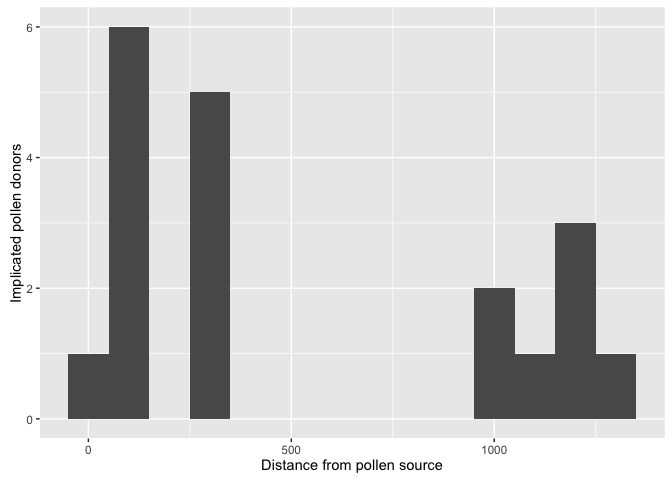

```r
data <- spiderplot_data(pat, cornus, longitude="X", latitude="Y")
data$Dist <- sqrt( (data$X-data$Xend)^2 + (data$Y-data$Yend)^2)
ggplot(data) + geom_histogram( aes(x=Dist),binwidth=100) + xlab("Distance from pollen source")  + ylab("Implicated pollen donors")
```

These values can also be viewed spatially using the `ggplot` function `geom_segments` highlighting the *a poster* paternity likelihood.

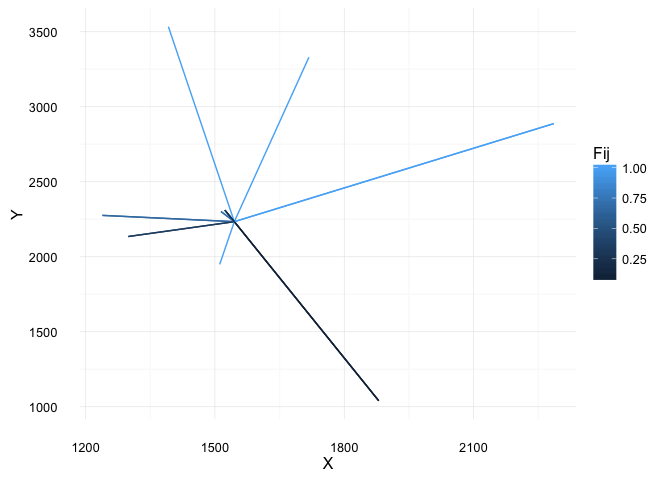

Spatial pattern of parentage for family 474 in the Cornus florida dataset. Darkness of the lines indicated fractional paternity.

There are a huge number of paternity studies out in the literature and it is a very powerful tool for the analysis of single mating events. Some of the shortcomings of this approach is that it is limited in scope to relatively small spatial scales and is particularly sensitive to individual-to-individual variation in mating patterns.

# Population Graphs

A population graph is a topological representation of within and among population genetic variance first introduced by Dyer & Nason (2004). It is particularly well suited to characterizing how spatial genetic variation is distributed among sites.

Here is the data we used in Garrick *et al.* (2013) describing the spatial variation in the Sonoran bark beetle, *Araptus attenuatus*, a bark beetle specializing on the plant *Euphorbia lomelii*.

```r
data(arapat)
summary(arapat)
```

```
##       Species      Cluster      Population        ID         Latitude
##  Cape     : 75   CBP-C :150   32     : 19   101_10A:  1   Min.   :23.08
##  Mainland : 36   NBP-C : 84   75     : 11   101_1A :  1   1st Qu.:24.59
##  Peninsula:252   SBP-C : 18   Const  : 11   101_2A :  1   Median :26.25
##                  SCBP-A: 75   12     : 10   101_3A :  1   Mean   :26.25
##                  SON-B : 36   153    : 10   101_4A :  1   3rd Qu.:27.53
##                               157    : 10   101_5A :  1   Max.   :29.33
##                               (Other):292   (Other):357
##    Longitude          LTRS          WNT            EN           EF
##  Min.   :-114.3   01:01 :147   03:03  :108   01:01  :225   01:01 :219
##  1st Qu.:-113.0   01:02 : 86   01:01  : 82   01:02  : 52   01:02 : 52
##  Median :-111.5   02:02 :130   01:03  : 77   02:02  : 38   02:02 : 90
##  Mean   :-111.7                02:02  : 62   03:03  : 22   NA's  :  2
##  3rd Qu.:-110.5                03:04  :  8   01:03  :  7
##  Max.   :-109.1                (Other): 15   (Other): 16
##                                NA's   : 11   NA's   :  3
##      ZMP           AML           ATPS          MP20
##  01:01 : 46   08:08  : 51   05:05  :155   05:07  : 64
##  01:02 : 51   07:07  : 42   03:03  : 69   07:07  : 53
##  02:02 :233   07:08  : 42   09:09  : 66   18:18  : 52
##  NA's  : 33   04:04  : 41   02:02  : 30   05:05  : 48
##               07:09  : 22   07:09  : 14   05:06  : 22
##               (Other):142   08:08  :  9   (Other):119
##               NA's   : 23   (Other): 20   NA's   :  5
```

A Population Graph is a geometric interpretation of the AMOVA genetic variance decomposition. To create Population Graphs we need to first take the raw genotypes and turn them into multivariate data (via `to_mv()`) and define a set of objects to act as nodes. In the beetle data, we’ll use the *Population* designation for the nodes.

To visualize any topology, we must first define a `layout` for the nodes. There are several algorithms that can be used, a common one is the Fruchterman-Reingold layout. The `igraph` library provides several options for visualizing network topologies, and here I show hot to label the vertices. For more information on plotting options and how decorate both nodes and edges see the documentation.

```r
x <- to_mv(arapat)
nodes <- arapat$Population
graph <- popgraph(x, nodes)
graph
```

```
## IGRAPH UNW- 39 71 --
## + attr: name (v/c), size (v/n), weight (e/n)
## + edges (vertex names):
##  [1] 101--102   101--32    102--32    12 --161   12 --165   12 --93
##  [7] 153--165   153--58    156--157   156--48    156--73    156--75
## [13] 157--48    157--Aqu   157--ESan  159--171   159--173   159--89
## [19] 160--168   160--169   160--93    160--SFr   161--162   161--165
## [25] 161--93    161--SFr   162--64    162--77    162--93    163--75
## [31] 163--Const 163--ESan  164--165   164--169   164--51    164--Const
## [37] 164--SFr   165--168   165--169   165--77    166--168   168--51
## [43] 168--58    168--64    168--77    169--58    169--93    169--SFr
## + ... omitted several edges
```

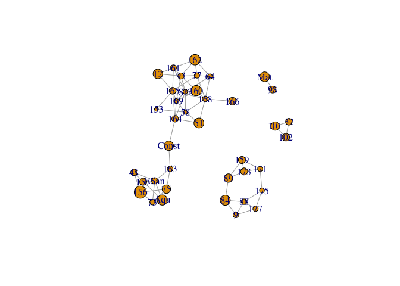

```r
l <- layout.fruchterman.reingold(graph)
plot(graph,layout=l,vertex.label=V(graph)$name)
```

We know that these data are a mixture of three putative species denoted mtDNA sequences and indicated by the *Species* column in the data set. Here is a summary of these data.

```r
t <- table(arapat$Species,arapat$Population)
t
```

```
##
##             101 102 12 153 156 157 159 160 161 162 163 164 165 166 168 169
##   Cape        0   0  0   0   6   8   0   0   0   0   3   2   0   2   0   0
##   Mainland    9   8  0   0   0   0   0   0   0   0   0   0   0   0   0   0
##   Peninsula   0   0 10  10   0   2   9  10  10  10   7   8  10   8  10  10
##
##             171 173 175 177 32 48 51 58 64 73 75 77 84 88 89  9 93 98 Aqu
##   Cape        0   0   0   0  0 10  0  0  0  8 10  1  0  0  0  0  0  3   4
##   Mainland    0   0   0   0 19  0  0  0  0  0  0  0  0  0  0  0  0  0   0
##   Peninsula  10  10   7  10  0  0  7  9  5  2  1  9  9 10 10  9 10  1   4
##
##             Const ESan Mat SFr
##   Cape          8    6   4   0
##   Mainland      0    0   0   0
##   Peninsula     3    2   1   9
```

We can color the nodes depending upon the identity of clade representation at the node-level. We will be very simple and identify the clades from the data in the table above. I will color the nodes by the species present in the population samples. Here I have the mainland Mexico populations as red, the cape peninsular populations as green, the peninsular populations as light blue and the populations with cape and peninsular populations as yellow.

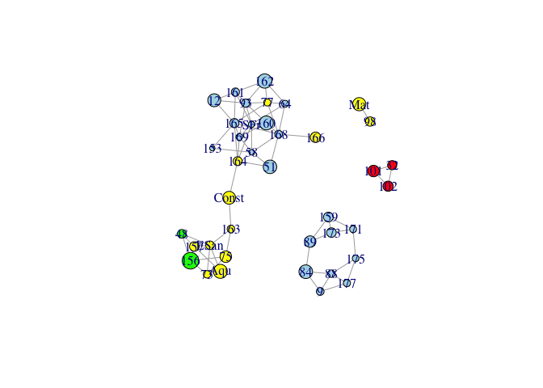

```r
colors <- rep("lightblue", length(V(graph)))
mainland_pops <- which( t[2,] > 0 )
colors[ mainland_pops ] <- "red"
cape_pops <- which( t[1,] > 0 )
colors[ cape_pops ] <- "green"
mixed_pops <- which( colSums(t>0) > 1 )
colors[ mixed_pops ] <- "yellow"
plot(graph,layout=l,vertex.label=V(graph)$name,vertex.color=colors)
```

So as we originally collected the data, we had NO IDEA that there were cryptic species in this data set, making it a rather surprising result once the data started coming in.

Another interesting component of this dataset that illustrates a few more skills in manipulating data in R is to focus just on the data from the main clade on the peninsula. This is by far the largest group of samples. To do this we: 1. Use only the *Peninsular* individuals 2. Get rid of the populations with say $N<5$ individuals 3. Make graph and examine the topology

```r
baja <- arapat[arapat$Species=="Peninsula",]
inds.per.pop <- lapply( partition(baja,"Population"), function(x) dim(x)[1] )
## Examine inds per pop to figure out which have <5 individuals save in smPops
smPops <- c("Const","ESan","157","73","Aqu","Mat","98","75")
baja <- baja[ !(baja$Population %in% smPops) , ]
x <- to_mv(baja)
nodes <- as.character( baja$Population )
graph <- popgraph( x, nodes)
graph
```

```
## IGRAPH UNW- 26 33 --
## + attr: name (v/c), size (v/n), weight (e/n)
## + edges (vertex names):
##  [1] 12 --161 153--58  159--171 159--173 159--89  160--169 160--SFr
##  [8] 161--162 161--165 161--93  161--SFr 162--166 162--93  164--165
## [15] 164--169 164--51  164--SFr 165--168 168--64  169--SFr 171--173
## [22] 171--175 173--89  175--177 175--88  177--88  177--9   64 --SFr
## [29] 77 --93  84 --88  84 --9   88 --9   93 --SFr
```

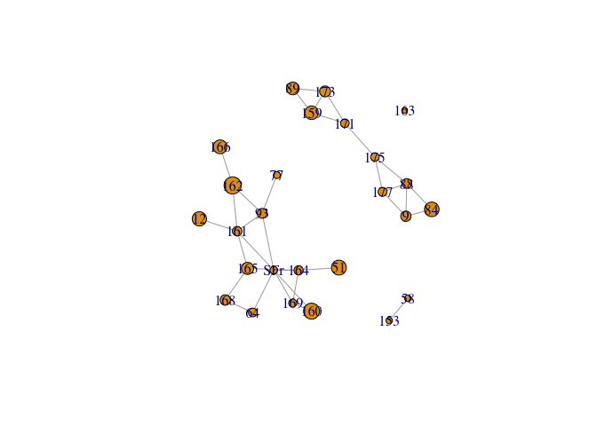

```r
l <- layout.fruchterman.reingold(graph)
plot(graph,layout=l,vertex.label=V(graph)$name)
```

From this plot, you can see even when we only focus on the true *Peninsula* species, there is still independence of genetic covariance among groups of populations (as demonstrated by their disconnectedness). And these groups, through other data sources, are probably due to separate refugia during the Pleistocene (you’ll have to read the paper for more info).

## More Advanced Plotting

To close this section, I wanted to show a bit more about how to plot these topologies in a way that may aid in intreptation. The code below does the following:  
1. Grab the coordiantes of the nodes from the peninsular populations. 2. Use the `ggmap` package to download a map tile from Google. This is a bit of a trial and error approach. Google has pre-defined zoom levels for its tiles and the `ggmap` function tries to figure out the best one to use given your coordinates. However, it is often not able to accomodate all your points. If you see, when you plot the data a message about “Removing X rows containing missing values” that means that the extent of the tile was too small to contain all your data points. As such, you must go back and manually adjust the zoom level until you get one that is correct. When you create the default map, you see the URL that is made to grab the tile and it has the estimated *zoom* value in it so it provides a good starting place. Decreasing this number will increase the extent of your map. 3. Add the coordiante data to the graph itself, using the `decorate_graph()` 4. Plot the map and overlay the edges and nodes.

[figure not shown]

Overlay of Peninsular populations of the Sonoran Desert bark beetle on a google map tile.

```r
require(ggmap)
coords <- strata_coordinates( arapat[ arapat$Species=="Peninsula",])
graph <- decorate_graph(graph, coords,stratum = "Stratum")
map <- population_map(coords,zoom=6)
ggmap(map) + geom_edgeset(aes(x=Longitude,y=Latitude),graph=graph) + geom_nodeset(aes(x=Longitude,y=Latitude),color="red", size=4, graph=graph)
```

# Comparing Networks

Finally, I’ll close by showing how we can compare topologies. If you have more than one topology there are several ways that you can examine the ‘similarity’ between them. Here we are going to cover two methods: - **Distance Congruence:** Distance congruence is a measure of correlation between node distances from the two topologies. Distance congruence is quantified via a Mantel test on distance matrices (via `to_matrix()`). If one or more of your topologies is disconnected, you need to get rid of the connections that will be denoted as *Inf* (e.g., they will be put as an infinite distance if they are disconnected.) - **Structural Congruence:** Structural congruence is a measure of the similarity in edges. This examines the likelihood of edges in both graphs.

For this we will use two simple graphs and I will make them from scratch by specifying the adjacency matrices of each. Below I specify the connections (then add the transpose of the matrix so that nodes are connected in both directions forming a non-directional graph), and finally make the two graphs.

```r
adj1 <- matrix(0,nrow=4,ncol=4)
adj1[1,2] <- adj1[2,3] <- adj1[2,4] <- adj1[3,4] <- 1
adj1 <- adj1 + t(adj1)
adj1
```

```
##      [,1] [,2] [,3] [,4]
## [1,]    0    1    0    0
## [2,]    1    0    1    1
## [3,]    0    1    0    1
## [4,]    0    1    1    0
```

```r
adj2 <- matrix(0,nrow=4,ncol=4)
adj2[1,3] <- adj2[1,2] <- adj2[2,3] <- adj2[2,4] <- 1
adj2 <- adj2 + t(adj2)
adj2
```

```
##      [,1] [,2] [,3] [,4]
## [1,]    0    1    1    0
## [2,]    1    0    1    1
## [3,]    1    1    0    0
## [4,]    0    1    0    0
```

These two graphs look like:

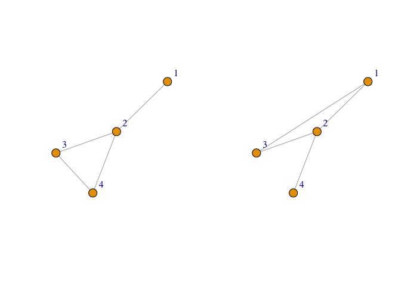

```r
graph1 <- graph.adjacency(adj1, mode="undirected" )
graph2 <- graph.adjacency(adj2, mode="undirected" )
l <- layout.fruchterman.reingold( graph1 )
par(mfrow=c(1,2))
plot(graph1, layout=l, vertex.label.dist=3)
plot(graph2, layout=l, vertex.label.dist=3)
```

These are fairly close in structure (there is only so much you can do with 4 nodes…). But lets look at each kind of congruence here. For distance congruence we can take the pairwise distance between all nodes and see if they are correlated using the Mantel test.

```r
dis1 <- as.dist( shortest.paths( graph1 ) )
dis2 <- as.dist( shortest.paths( graph2 ) )
mantel( dis1 , dis2 )
```

```
## 'nperm' >= set of all permutations: complete enumeration.
```

```
## Set of permutations < 'minperm'. Generating entire set.
```

```
##
## Mantel statistic based on Pearson's product-moment correlation
##
## Call:
## mantel(xdis = dis1, ydis = dis2)
##
## Mantel statistic r:  0.25
##       Significance: 0.58333
##
## Upper quantiles of permutations (null model):
##   90%   95% 97.5%   99%
## 0.250 0.925 1.000 1.000
## Permutation: free
## Number of permutations: 23
```

For structural congruence we can use either a hypergeometric approach (harder) or a $\chi^2$ one that has a correlation associated with it (simpler). For the $\chi^2$ approach we need to count the number of edges: 1. Both graphs have in common (call this `a`) 2. First graph has but not second (`b`) 3. Second graph has but not in first (`c`) 4. Both graphs do not have (`d`)

Then the equation is

$$\chi^2 = \frac{N(ad-bc)^2}{ (a+b)*(c+d)*(a+c)*(b+d)}$$

which is distributed as a $\chi^2$ statistic with $df=1$ (with $N=a+b+c+d$) and can be used to test significance. The correlation for this relationship is:

$$\Phi = \sqrt{\chi^2/N}$$

From the graphs above we can use the lower triangle of the adjacency matrix to find these as:

```r
edges1 <- adj1[ lower.tri(adj1)]
edges2 <- adj2[ lower.tri(adj2)]
cbind(edges1,edges2)
```

```
##      edges1 edges2
## [1,]      1      1
## [2,]      0      1
## [3,]      0      0
## [4,]      1      1
## [5,]      1      1
## [6,]      1      0
```

```r
a <- sum( edges1==1 & edges2==1)
a
```

```
## [1] 3
```

```r
b <- sum( edges1==1 & edges2==0)
b
```

```
## [1] 1
```

```r
c <- sum( edges1==0 & edges2==1)
c
```

```
## [1] 1
```

```r
d <- sum( edges1==0 & edges2==0)
d
```

```
## [1] 1
```

```r
N <- a+b+c+d
chi <- (N * (a*d-b*c)^2) / ( (a+b)*(c+d)*(a+c)*(b+d))
chi
```

```
## [1] 0.375
```

```r
1-pchisq(chi,df=1)
```

```
## [1] 0.5402914
```

and the correlation between the structures of these two are:

```r
phi <- sqrt(chi/N)
phi
```

```
## [1] 0.25
```

Which is a bit like the distance congruence value, no? This does not have to be the case in real-world comparisons but just happens to work out this way in these simple data examples.

# Questions

1. *Think about the study system you are working on and determine what kinds of questions the analysis of parent/offspring data may be useful.*
2. *When examining parent/offspring data, there is some ambiguity when the mother and offspring have the same heterozygous genotype. In general, what is the likelihood of this occurring and how does it change with allele frequencies and diversity?*
3. *What kind of bias is introduced into your genetic data if you do not remove the maternal contribution to each offspring? How might this influence your results? Can you estimate the change in allele frequencies ($\delta p$) between the unreduced and reduced offspring genotypes?*
4. *Look at the 2Gener analysis of pollen pool structure. Is there anything odd about the output? Is there anything you would suggest that could be done to increase the effectiveness of this analysis?*
5. *Can you design a graph that is negatively correlated to **graph1** as above.*
6. *Look at the way graphs are plotted using the **layout** option to the plot function. Can you think of a way to plot a network onto a spatial overlay? (hint: you may want to look at `?igraph.plotting` for some hints)*